# Phần 03 - Tạo Facebook Data Analysis Report

Welcome bạn đến phần 3 của bài **Lab Facebook Social Analysis Report** của **Microsoft Student Partners Vietnam** nhé. Bài Lab này do **MSP Lại Trung Minh Đức (Technical Trainer)** trình bày và hướng dẫn.

Trong phần 3 này, bạn sẽ dùng **Python** để khai thác và phân tích dữ liệu Facebook của cá nhân bạn ở phần 2. Phần phân tích bao gồm:

- Thống kê mô tả Feeds, Comments và Reactions để đánh giá những cái "nhất".
- Tìm các n-TOP của Feeds, Comments, và Reactions
- Tạo WordCloud cho Feeds (3 WordCloud-s)
- Tạo Chart cho Comments theo thời gian (8 Chart-s)

Để thực hành phần Lab này, bạn cần có

- **User ID** từ Facebook Graph API
- **MongoDB URL** và **Database name** đã có dữ liệu ở phần 2

Bạn cũng sẽ cần cài đặt packages:

- WordCloud

*Let's get started*

## 0. Cài đặt Packages cần thiết

```python
!pip install WordCloud
```

```
grpcio 1.11.0 has requirement protobuf>=3.5.0.post1, but you'll have protobuf 3.4.1 which is incompatible.
pyasn1-modules 0.2.1 has requirement pyasn1<0.5.0,>=0.4.1, but you'll have pyasn1 0.1.9 which is incompatible.
```

## 1. Import các gói cần thiết, khai báo các hằng số, và kết nối Database

```python
# Bạn thay thế link dưới đây thành MONGO_URL của bạn nhé, nhớ là nội dung phải nằm trong dấu ''
# Nếu nó nằm ngoài thì bạn sẽ thấy chữ màu đen, còn nếu nằm trong thì thấy chữ màu đỏ.
MONGO_URL = 'mongodb://mspvn:mspvn@ds014648.mlab.com:14648/facebook-data'

# Bạn thay thế chuỗi dưới đây thành DB_NAME của bạn nhé, nhớ là phải nằm trong dấu ''
DB_NAME = 'facebook-data'

# Bạn thay thế chuỗi dưới đây thành TARGET_USER_ID của bạn nhé, nhớ là phải nằm trong dấu ''
TARGET_USER_ID = '685724974810689'

# Nếu bạn muốn tìm TOP 50, thay ở đây thành 50
# Nếu bạn muốn tìm TOP 100, thay ở đây thành 100
LIMIT_TOP = 10
```

```python
from pymongo import MongoClient
import pandas as pd
import matplotlib.pyplot as plt
import numpy as np

client = MongoClient(MONGO_URL)
db = client[DB_NAME]
```

## 2. Get Data từ Database vào Pandas DataFrame và tiền xử lý

- Get Data từ MongoDB vào DataFrame
- Data ở đây là tất cả các dòng dữ liệu có **target_user_id = TARGET_USER_ID** ở trên

```python
feeds = pd.DataFrame(list(db.feeds.find({'target_user_id': TARGET_USER_ID})))
comments = pd.DataFrame(list(db.comments.find({'target_user_id': TARGET_USER_ID})))
reactions = pd.DataFrame(list(db.reactions.find({'target_user_id': TARGET_USER_ID})))
```

- Nếu bạn có ý định public code và report về Facebook này cho người khác xem thì mình khuyên là bạn nên chạy đoạn code dưới đây.
- Cách chạy: Ctrl + A (chọn tất cả) và Ctrl + / (để un-comment)
- Sau đó Restart Kernel và Run All, bạn sẽ thấy **user_id**, **item_id**, **target_feed_id** đã được chuyển thành một dãy số khác. Mục đích là để bảo vệ bạn, và bạn bè bạn.

```python
import hashlib
feeds['item_id'] = [hashlib.md5(x.encode()).hexdigest() for x in feeds['item_id']]

comments['item_id'] = [hashlib.md5(x.encode()).hexdigest() for x in comments['item_id']]
comments['target_feed_id'] = [hashlib.md5(x.encode()).hexdigest() for x in comments['target_feed_id']]
comments['user_id'] = [hashlib.md5(x.encode()).hexdigest() for x in comments['user_id']]

reactions['target_feed_id'] = [hashlib.md5(x.encode()).hexdigest() for x in reactions['target_feed_id']]
reactions['user_id'] = [hashlib.md5(x.encode()).hexdigest() for x in reactions['user_id']]

TARGET_USER_ID = hashlib.md5(TARGET_USER_ID.encode()).hexdigest()
```

- Chạy **DataFrame.head()** để xem dữ liệu
- DataFrame hiện tại ta đang có là **feeds, reactions, comments**

```python
feeds.head()
```

|  | _id | angry | comments_count | crawlStatus | created_time | description | haha | item_id | like | link | love | message | sad | target | target_user_id | title | wow |
| --- | --- | --- | --- | --- | --- | --- | --- | --- | --- | --- | --- | --- | --- | --- | --- | --- | --- |
| 0 | 5af83bfd4f9cf700719a92b5 | 0 | 2 | DONE | 2016-02-14T01:01:28+0000 |  | 0 | 1b642ee9c992ac070af9bfd5bfb39ae9 | 7 | None | 0 | Năm nào mở tour cũng failed @@\nThôi kệ, số mì... | 0 |  | 685724974810689 |  | 0 |
| 1 | 5af83bfd4f9cf700719a92af | 0 | 1 | DONE | 2016-03-02T08:50:43+0000 | Ko ngờ Avast nó chơi lầy vầy :)) | 0 | 122dc1b14364441e91e2703f140cca6b | 7 | None | 0 | Ko ngờ Avast nó chơi lầy vầy :)) | 0 | https://www.facebook.com/photo.php?fbid=103200... | 685724974810689 |  | 0 |
| 2 | 5af83bfd4f9cf700719a8feb | 0 | 0 | DONE | 2016-02-05T12:16:18+0000 | 2014 Facebook chọn hình đẹp ghê :) | 0 | ef9965a1d628c4a1bda8936d32c6fb7b | 8 | None | 0 | 2014 Facebook chọn hình đẹp ghê :) | 0 | https://www.facebook.com/photo.php?fbid=101811... | 685724974810689 |  | 0 |
| 3 | 5af83bfd4f9cf700719a9101 | 0 | 1 | DONE | 2016-02-06T02:55:36+0000 | Dọn lại nhà cửa, dọn lại bàn học, gặp được một... | 0 | 30cb9a75011562bb68065049d01e702d | 10 | None | 0 | Dọn lại nhà cửa, dọn lại bàn học, gặp được một... | 0 | https://www.facebook.com/photo.php?fbid=101854... | 685724974810689 |  | 0 |
| 4 | 5af83bfd4f9cf700719a93d6 | 0 | 1 | DONE | 2016-02-14T07:23:36+0000 | Chắc chuẩn bị làm Blog tiếng Anh, chứ để người... | 0 | 07da0a79114cd18d6e14451076ae7300 | 11 | None | 0 | Chắc chuẩn bị làm Blog tiếng Anh, chứ để người... | 0 | https://www.facebook.com/photo.php?fbid=102259... | 685724974810689 |  | 0 |

- Thay đổi vị trí cột của dữ liệu, và xoá bớt những cột không cần thiết.

```python
feeds = feeds[['item_id', 'message', 'created_time', 'comments_count',
                'description', 'angry', 'like', 'haha', 'love', 'sad', 'wow']]
comments = comments[['item_id', 'message', 'created_time', 'like_count', 'target_feed_id', 'user_name' , 'user_id']]
reactions = reactions[['user_name', 'user_id', 'react_type', 'target_feed_id']]
```

- Chạy lại **DataFrame.head()** để xem các cột đã thay đổi và đã đẹp như mong đợi chưa?
- DataFrame hiện tại ta đang có là **feeds, reactions, comments**

```python
feeds.head()
```

|  | item_id | message | created_time | comments_count | description | angry | like | haha | love | sad | wow |
| --- | --- | --- | --- | --- | --- | --- | --- | --- | --- | --- | --- |
| 0 | 1b642ee9c992ac070af9bfd5bfb39ae9 | Năm nào mở tour cũng failed @@\nThôi kệ, số mì... | 2016-02-14T01:01:28+0000 | 2 |  | 0 | 7 | 0 | 0 | 0 | 0 |
| 1 | 122dc1b14364441e91e2703f140cca6b | Ko ngờ Avast nó chơi lầy vầy :)) | 2016-03-02T08:50:43+0000 | 1 | Ko ngờ Avast nó chơi lầy vầy :)) | 0 | 7 | 0 | 0 | 0 | 0 |
| 2 | ef9965a1d628c4a1bda8936d32c6fb7b | 2014 Facebook chọn hình đẹp ghê :) | 2016-02-05T12:16:18+0000 | 0 | 2014 Facebook chọn hình đẹp ghê :) | 0 | 8 | 0 | 0 | 0 | 0 |
| 3 | 30cb9a75011562bb68065049d01e702d | Dọn lại nhà cửa, dọn lại bàn học, gặp được một... | 2016-02-06T02:55:36+0000 | 1 | Dọn lại nhà cửa, dọn lại bàn học, gặp được một... | 0 | 10 | 0 | 0 | 0 | 0 |
| 4 | 07da0a79114cd18d6e14451076ae7300 | Chắc chuẩn bị làm Blog tiếng Anh, chứ để người... | 2016-02-14T07:23:36+0000 | 1 | Chắc chuẩn bị làm Blog tiếng Anh, chứ để người... | 0 | 11 | 0 | 0 | 0 | 0 |

```python
comments.head()
```

|  | item_id | message | created_time | like_count | target_feed_id | user_name | user_id |
| --- | --- | --- | --- | --- | --- | --- | --- |
| 0 | 824b194509dfa6cda6e166a331ffc4a8 | tour j ọ? | 2016-02-14T01:31:15+0000 | 0 | 1b642ee9c992ac070af9bfd5bfb39ae9 | Cao Kỳ Duyên | 8deada5f22af3d97c1206fb53bd77d0f |
| 1 | b4b2e4db8c7949b82d2c81f00c05a244 | Bao Nhu Tran: 1 năm r :)) năm nay hết dám mở t... | 2017-02-14T02:52:10+0000 | 0 | 1b642ee9c992ac070af9bfd5bfb39ae9 | Duc Lai Trung Minh | 866a9622b0573cc54e528a7ad684fab2 |
| 2 | 6cb05df93aa4279d17f11dc7a40ad3c6 | Anh mua hàng trên này à :) | 2016-03-02T15:05:14+0000 | 0 | 122dc1b14364441e91e2703f140cca6b | Ngô Hùng | 9346dd50132dc4ce6ced464855917c9a |
| 3 | 47834ab1187c3ef67a6243e74623f644 | Spam k àh :D | 2016-02-14T13:14:50+0000 | 0 | 07da0a79114cd18d6e14451076ae7300 | Truong An Vo | 48eeda1a5ffb983746ca0d48641744c1 |
| 4 | 2ce0dfcd168fd445eb84022524fc2034 | Ờ trò này hay đó :D đỡ tốn thời gian dã man | 2016-01-25T14:49:35+0000 | 0 | ca23c1d7adcfd139a0bacaca81f90df8 | Truong An Vo | 48eeda1a5ffb983746ca0d48641744c1 |

```python
reactions.head()
```

|  | user_name | user_id | react_type | target_feed_id |
| --- | --- | --- | --- | --- |
| 0 | Minh Hiền | 4a281b9f1e623da14d95abc9cb437cb0 | LIKE | 1b642ee9c992ac070af9bfd5bfb39ae9 |
| 1 | Phat Vo Tan | 2117b5120054bdf08307e4c5c14d263c | LIKE | 1b642ee9c992ac070af9bfd5bfb39ae9 |
| 2 | Tín Lý | fc3bd7ca037e086c0fc50e0ad4412330 | LIKE | 1b642ee9c992ac070af9bfd5bfb39ae9 |
| 3 | Tam Minh Nguyen | 8791ababcfe3b7dcf1e5e2964fe382f8 | LIKE | 1b642ee9c992ac070af9bfd5bfb39ae9 |
| 4 | Mi Chon | 12760baaca6f333b6dae04e38c69f1ef | LIKE | 1b642ee9c992ac070af9bfd5bfb39ae9 |

- Quan sát **Time** trong cột **created_time** sẽ thấy Time đang ở múi giờ +0000, cần chuyển về múi giờ +0007
- Định dạng của **Time** hiện tại cũng là **String**, cần chuyển về dạng **DateTime** để có thể lấy **Hour, Minute, Second, Day, Month, Year** dễ dàng

```python
from datetime import datetime, timezone
from dateutil import tz

to_zone = tz.gettz('Asia/Ho_Chi_Minh')

feeds['created_time'] = [datetime.strptime(x, "%Y-%m-%dT%H:%M:%S%z")
                         .replace(tzinfo=timezone.utc)
                         .astimezone(tz=to_zone)
                         for x in feeds['created_time']]
comments['created_time'] = [datetime.strptime(x, "%Y-%m-%dT%H:%M:%S%z")
                            .replace(tzinfo=timezone.utc)
                            .astimezone(tz=to_zone)
                            for x in comments['created_time']]
```

- Kiểm tra lại dữ liệu lần nữa xem ổn chưa để chuyển sang phần kế tiếp.

```python
comments.head()
```

|  | item_id | message | created_time | like_count | target_feed_id | user_name | user_id |
| --- | --- | --- | --- | --- | --- | --- | --- |
| 0 | 824b194509dfa6cda6e166a331ffc4a8 | tour j ọ? | 2016-02-14 08:31:15+07:00 | 0 | 1b642ee9c992ac070af9bfd5bfb39ae9 | Cao Kỳ Duyên | 8deada5f22af3d97c1206fb53bd77d0f |
| 1 | b4b2e4db8c7949b82d2c81f00c05a244 | Bao Nhu Tran: 1 năm r :)) năm nay hết dám mở t... | 2017-02-14 09:52:10+07:00 | 0 | 1b642ee9c992ac070af9bfd5bfb39ae9 | Duc Lai Trung Minh | 866a9622b0573cc54e528a7ad684fab2 |
| 2 | 6cb05df93aa4279d17f11dc7a40ad3c6 | Anh mua hàng trên này à :) | 2016-03-02 22:05:14+07:00 | 0 | 122dc1b14364441e91e2703f140cca6b | Ngô Hùng | 9346dd50132dc4ce6ced464855917c9a |
| 3 | 47834ab1187c3ef67a6243e74623f644 | Spam k àh :D | 2016-02-14 20:14:50+07:00 | 0 | 07da0a79114cd18d6e14451076ae7300 | Truong An Vo | 48eeda1a5ffb983746ca0d48641744c1 |
| 4 | 2ce0dfcd168fd445eb84022524fc2034 | Ờ trò này hay đó :D đỡ tốn thời gian dã man | 2016-01-25 21:49:35+07:00 | 0 | ca23c1d7adcfd139a0bacaca81f90df8 | Truong An Vo | 48eeda1a5ffb983746ca0d48641744c1 |

## 3. Thống kê mô tả dữ liệu với DataFrame.describe()

- Đưa ra bảng thống kê mô tả (Descriptive Statistical) của dữ liệu.
- Nếu dữ liệu là số (numeric) --> Bảng thống kê sẽ có: count, mean, std, min, max,...
- Nếu dữ liệu là chữ (string) --> Bảng thống kê sẽ có: count, unique, top, freq

Một lưu ý khi dùng describe:

- To call describe() on just the numerical columns use describe(include = [np.number])
- To call describe() on just the objects (strings) using describe(include = ['O'])
- Ref: https://stackoverflow.com/questions/24524104/pandas-describe-is-not-returning-summary-of-all-columns

```python
feeds.describe()
```

|  | comments_count | angry | like | haha | love | sad | wow |
| --- | --- | --- | --- | --- | --- | --- | --- |
| count | 1195.000000 | 1195.000000 | 1195.000000 | 1195.000000 | 1195.000000 | 1195.000000 | 1195.000000 |
| mean | 1.661088 | 0.035983 | 10.754812 | 0.921339 | 0.460251 | 0.081172 | 0.162343 |
| std | 2.120677 | 0.215506 | 12.127918 | 2.099814 | 1.570472 | 0.645255 | 0.584920 |
| min | 0.000000 | 0.000000 | 0.000000 | 0.000000 | 0.000000 | 0.000000 | 0.000000 |
| 25% | 0.000000 | 0.000000 | 3.000000 | 0.000000 | 0.000000 | 0.000000 | 0.000000 |
| 50% | 1.000000 | 0.000000 | 7.000000 | 0.000000 | 0.000000 | 0.000000 | 0.000000 |
| 75% | 2.000000 | 0.000000 | 13.000000 | 1.000000 | 0.000000 | 0.000000 | 0.000000 |
| max | 17.000000 | 2.000000 | 143.000000 | 38.000000 | 38.000000 | 13.000000 | 8.000000 |

```python
reactions.describe()
```

|  | user_name | user_id | react_type | target_feed_id |
| --- | --- | --- | --- | --- |
| count | 14858 | 14858 | 14858 | 14858 |
| unique | 798 | 810 | 8 | 1135 |
| top | Phuong Tran Long Nhat | 8282f79faecb54364d3f56568840aa28 | LIKE | 1f6bcfedec04076e90edb853d272c65f |
| freq | 664 | 664 | 12866 | 164 |

```python
comments.describe(include = ['O'])
```

|  | item_id | message | target_feed_id | user_name | user_id |
| --- | --- | --- | --- | --- | --- |
| count | 1982 | 1982 | 1982 | 1982 | 1982 |
| unique | 1982 | 1881 | 747 | 275 | 279 |
| top | a9da410e2beeadd0ae3ff024bcd2f490 |  | ea16b8cf2a31afdb6324dce04769a819 | Truong An Vo | 48eeda1a5ffb983746ca0d48641744c1 |
| freq | 1 | 72 | 17 | 131 | 131 |

## 4. Tìm n-top bằng DataFrame.nlargest(n, columns_list)

- Mục đích của function là để lấy **n** dòng từ trên xuống sắp xếp theo thứ tự được sắp xếp trên 1 hoặc nhiều cột. Cần lưu ý là các cột sắp xếp phải là cột có trị số (numeric)

```python
limitTop = LIMIT_TOP
```

### Tự ghi chú: Loại n-top cho cái gì

### TOP 10 Feeds nhiều Likes nhất

```python
# feeds.nlargest(limitTop, ['comments_count'])
# feeds.nlargest(limitTop, ['angry'])
# feeds.nlargest(limitTop, ['love'])
feeds.nlargest(limitTop, ['like'])
# feeds.nlargest(limitTop, ['sad'])
# feeds.nlargest(limitTop, ['haha'])
# feeds.nlargest(limitTop, ['wow'])
```

[output not shown]

### Vấn đề của comments và reactions

- Đối với **Feeds** thì có các cột **comments_count, like, love,...** là những cột có giá trị số. Do đó có thể dễ dàng dùng **nlargest()** để tìm **Top-N** trực tiếp.
- Đối với **Comments** và **Reactions** thì không như thế. Bạn có thể dùng **.head()** để xem, thì thấy cả 2 collections này đều gần như không có các cột có giá trị số, nên để trả lời câu hỏi: **Ai là đã comment hoặc react tôi nhiều nhất?** thì mình phải đi theo một hướng khác...

```python
# Copy code here (6)

comments.head()
```

|  | item_id | message | created_time | like_count | target_feed_id | user_name | user_id |
| --- | --- | --- | --- | --- | --- | --- | --- |
| 0 | 824b194509dfa6cda6e166a331ffc4a8 | tour j ọ? | 2016-02-14 08:31:15+07:00 | 0 | 1b642ee9c992ac070af9bfd5bfb39ae9 | Cao Kỳ Duyên | 8deada5f22af3d97c1206fb53bd77d0f |
| 1 | b4b2e4db8c7949b82d2c81f00c05a244 | Bao Nhu Tran: 1 năm r :)) năm nay hết dám mở t... | 2017-02-14 09:52:10+07:00 | 0 | 1b642ee9c992ac070af9bfd5bfb39ae9 | Duc Lai Trung Minh | 866a9622b0573cc54e528a7ad684fab2 |
| 2 | 6cb05df93aa4279d17f11dc7a40ad3c6 | Anh mua hàng trên này à :) | 2016-03-02 22:05:14+07:00 | 0 | 122dc1b14364441e91e2703f140cca6b | Ngô Hùng | 9346dd50132dc4ce6ced464855917c9a |
| 3 | 47834ab1187c3ef67a6243e74623f644 | Spam k àh :D | 2016-02-14 20:14:50+07:00 | 0 | 07da0a79114cd18d6e14451076ae7300 | Truong An Vo | 48eeda1a5ffb983746ca0d48641744c1 |
| 4 | 2ce0dfcd168fd445eb84022524fc2034 | Ờ trò này hay đó :D đỡ tốn thời gian dã man | 2016-01-25 21:49:35+07:00 | 0 | ca23c1d7adcfd139a0bacaca81f90df8 | Truong An Vo | 48eeda1a5ffb983746ca0d48641744c1 |

# 5.Tìm n-top có có group với DataFrame.groupby(columns_list)

- Mục tiêu của hàm này là để gom nhóm data giống nhau theo cột (hoặc nhiều cột)
- Thường hàm sẽ được dùng với một số hàm khác theo chaining để tính toán, hoặc tạo ra cột mới.

Quay trở lại data **Comments** và **Reactions**, ta thấy có thể gom nhóm 2 cột **user_id** và cột **user_name**. Do đó, ta dùng codeblock dưới đây để gom nhóm --> tạo cột mới tên **counts** --> dùng cột **counts** này để tìm n-top.

Reference: https://stackoverflow.com/questions/19384532/how-to-count-number-of-rows-in-a-group-in-pandas-group-by-object

### Tự ghi chú: Loại n-top cho cái gì

### TOP 10 Users comment nhiều nhất

```python
comments.groupby(['user_id', 'user_name']).size().reset_index(name='counts').nlargest(limitTop, ['counts'])
```

|  | user_id | user_name | counts |
| --- | --- | --- | --- |
| 82 | 48eeda1a5ffb983746ca0d48641744c1 | Truong An Vo | 131 |
| 141 | 866a9622b0573cc54e528a7ad684fab2 | Duc Lai Trung Minh | 103 |
| 86 | 4c0f51337972b4591ab649b7d7c26bf0 | Hoàng Tuấn | 101 |
| 151 | 8deada5f22af3d97c1206fb53bd77d0f | Cao Kỳ Duyên | 64 |
| 56 | 32738f665288a09bd37fbda8f6e68c4e | Việt Hùng | 54 |
| 107 | 6259841ef36efde1dd06a6c627e02784 | Tuong Nguyen Minh Nhat | 47 |
| 170 | a1f854b74dbc4e85fb7d4a814449e4aa | Du Van Nguyen | 42 |
| 250 | e7420a871431073fba9f3b49ae0daf30 | Phạm Quốc Cường | 41 |
| 63 | 38d8d59cbc3ad24665425325046c13c8 | Minh Phuc Lưu | 38 |
| 164 | 9a4edaea30b272f0f31d797daa672923 | Hồ Vy | 37 |

### TOP 10 Users Reacts nhiều nhất

```python
reactions.groupby(['user_id', 'user_name']).size().reset_index(name='counts').nlargest(limitTop, ['counts'])
```

|  | user_id | user_name | counts |
| --- | --- | --- | --- |
| 393 | 8282f79faecb54364d3f56568840aa28 | Phuong Tran Long Nhat | 664 |
| 178 | 3bb6ac80b0e1640bf5d6ccea03a14f90 | Mary Joséphine | 486 |
| 145 | 3029b921b0931bc09598cf17a8277735 | Hoàng Lê Hải Thanh | 362 |
| 222 | 4a281b9f1e623da14d95abc9cb437cb0 | Minh Hiền | 344 |
| 244 | 517855c840530e8c3cd3ef05801dd848 | Phuong Thao Tran | 342 |
| 218 | 48eeda1a5ffb983746ca0d48641744c1 | Truong An Vo | 312 |
| 588 | bda4a0062954e3e6a4d3815208c6efcb | Lê Minh | 299 |
| 365 | 79c13bd7029e349274c09a77a064d37e | Nam Pham Hoai | 265 |
| 347 | 738104a4c7f29d876ea4d68ce1319988 | Nhật Hà | 238 |
| 299 | 6259841ef36efde1dd06a6c627e02784 | Tuong Nguyen Minh Nhat | 229 |

### TOP 10 Users Reacts theo loại React nhiều nhất

```python
reactions.groupby(['user_id', 'user_name', 'react_type']).size().reset_index(name='counts').nlargest(limitTop, ['counts'])
```

|  | user_id | user_name | react_type | counts |
| --- | --- | --- | --- | --- |
| 605 | 8282f79faecb54364d3f56568840aa28 | Phuong Tran Long Nhat | LIKE | 572 |
| 276 | 3bb6ac80b0e1640bf5d6ccea03a14f90 | Mary Joséphine | LIKE | 416 |
| 217 | 3029b921b0931bc09598cf17a8277735 | Hoàng Lê Hải Thanh | LIKE | 333 |
| 388 | 517855c840530e8c3cd3ef05801dd848 | Phuong Thao Tran | LIKE | 327 |
| 919 | bda4a0062954e3e6a4d3815208c6efcb | Lê Minh | LIKE | 292 |
| 564 | 79c13bd7029e349274c09a77a064d37e | Nam Pham Hoai | LIKE | 265 |
| 351 | 4a281b9f1e623da14d95abc9cb437cb0 | Minh Hiền | LIKE | 256 |
| 535 | 738104a4c7f29d876ea4d68ce1319988 | Nhật Hà | LIKE | 226 |
| 462 | 6259841ef36efde1dd06a6c627e02784 | Tuong Nguyen Minh Nhat | LIKE | 223 |
| 145 | 2117b5120054bdf08307e4c5c14d263c | Phat Vo Tan | LIKE | 203 |

### Thống kê các loại Reactions

```python
reactions.groupby(['react_type']).size().reset_index(name='counts')
```

|  | react_type | counts |
| --- | --- | --- |
| 0 | ANGRY | 43 |
| 1 | HAHA | 1103 |
| 2 | LIKE | 12866 |
| 3 | LOVE | 550 |
| 4 | PRIDE | 2 |
| 5 | SAD | 97 |
| 6 | THANKFUL | 3 |
| 7 | WOW | 194 |

# 6. Tạo WordCloud

- Định nghĩa: WordCloud là một tấm hình - được tạo từ sự sắp xếp rất nhiều từ, cụm từ - Kích thước của từng từ sẽ dựa trên độ quan trọng / tần suất xuất hiện của từ.
- Mục đích: Nắm nhanh qua nội dung các Feeds/Comments thông qua WordCloud

### Quy trình tạo WordCloud đơn giản

- Đưa nội dung cần tạo WordCloud vào 1 biến String (nội dung sách, nội dung messages,...).
- Import các package cần thiết của WordCloud.
- Import các STOPWORDS package tuỳ theo từng loại ngôn ngữ.
- Chạy WordCloud
- Xem Result rồi điều chỉnh lại thông số cho hợp lý
- Lưu WordCloud result vào file ảnh

Nếu bạn thắc mắc STOPWORDS là gì thì theo mình hiểu, đó là những từ đệm được thêm vào văn bản để làm cho bài văn smooth hơn, mềm mại hơn. Thường các từ này chiếm khá nhiều chỗ trong bài của bạn nên bạn có thể bỏ nó đi. Bạn có thể xem thêm tại: https://en.wikipedia.org/wiki/Stop_words

STOPWORDS tiếng Anh mình sẽ dùng default của WordCloud STOPWORDS tiếng Việt mình sẽ tự parse file tại http://xltiengviet.wikia.com/wiki/Danh_s%C3%A1ch_stop_word

Guide config WordCloud: https://amueller.github.io/word_cloud/generated/wordcloud.WordCloud.html

Phía trên là quy trình đơn giản, bây giờ là cách làm của mình dành cho việc tạo WordCloud cho nội dung Feeds của mình.

### Chuẩn bị tạo WordCloud

```python
tempFeedsString = " ".join(str(x) for x in feeds['message'])
tempCommentsString = " ".join(str(x) for x in comments['message'])
```

```python
from wordcloud import WordCloud, STOPWORDS
from PIL import Image
from os import path, getcwd

# Chuẩn bị cắt StopWords thành array
vietnamStopwords = 'bị,bởi,cả,các,cái,cần,càng,chỉ,chiếc,cho,chứ,chưa,chuyện,có,có thể,cứ,của,cùng,cũng,đã,đang,đây,để,đến nỗi,đều,điều,do,đó,được,dưới,gì,khi,không,là,lại,lên,lúc,mà,mỗi,một cách,này,nên,nếu,ngay,nhiều,như,nhưng,những,nơi,nữa,phải,qua,ra,rằng,rằng,rất,rất,rồi,sau,sẽ,so,sự,tại,theo,thì,trên,trước,từ,từng,và,vẫn,vào,vậy,vì,việc,với,vừa'
vietnamStopwords = vietnamStopwords.split(',')
needToRemoveWords = ['None']
```

### Tạo WordCloud

- Thông thường khi tạo WordCloud, bạn sẽ muốn xem WC trước khi có ý định xuất ra file ảnh, do đó 2 thông số về **width, height** hiện tại đang được mình *tạm bỏ qua* bằng dấu **#**.

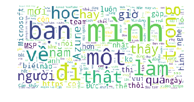

```python
# Tạo Word Cloud
wordcloud = WordCloud(
    stopwords = vietnamStopwords + list(STOPWORDS) + needToRemoveWords,
    max_words = 1000,
    background_color = 'white',
    # width=1600, height=800
).generate(tempFeedsString)

# Print result ra Jupyter
plt.imshow(wordcloud)
plt.axis("off")
plt.show()
```

- Sau khi nhìn thấy được WC overview rồi, bạn sẽ bỏ dấu **#** ở **width, height** đi.
- Đồng thời nếu bạn muốn chỉnh size (pixel) (hoặc thêm số từ ngữ) thì hãy chỉnh ở đoạn này.
- Ở đây, mình chỉnh **max_words = 2000** và **width = 1600, height = 800**

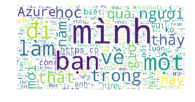

```python
# Tạo Word Cloud
wordcloud = WordCloud(
    stopwords = vietnamStopwords + list(STOPWORDS) + needToRemoveWords,
    max_words = 2000,
    background_color = 'white',
    width=1600, height=800
).generate(tempFeedsString)

# Print result ra Jupyter
plt.imshow(wordcloud)
plt.axis("off")
plt.show()
```

- Giờ thì mình xuất KQ ra file bằng câu code dưới đây là OK.
- File sẽ được lưu dưới tên **WC1.png** nằm ở ngoài Azure Notebooks Library của bạn

```python
wordcloud.to_file('WC1.png')
```

```
<wordcloud.wordcloud.WordCloud at 0x7fd15dfb8438>
```

### Tạo WordCloud có Masked

- Đôi lúc bạn muốn tạo WordCloud nằm bên trong một đối tượng, hình ảnh khác (VD: hình nước Việt Nam,...)
- Để dễ hình dung thì bạn có thể xem hình dưới đây

[figure not shown]

- Mình cũng đã chuẩn bị sẵn cho bạn 2 tấm **MASK.png** và **MASK-2.png** để các bạn thực hành rồi đó.

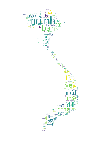

```python
# Đọc tấm hình vào biến NumPy
d = getcwd()
mask = np.array(Image.open(path.join(d, "MASK.png")))

# Làm WordCloud
wordcloudMask = WordCloud(
    stopwords = vietnamStopwords, max_words = 1000,
    background_color = 'white',
    # width=1600, height=800,
    mask = mask).generate(tempFeedsString)

plt.imshow(wordcloudMask)
plt.axis("off")
plt.show()
```

Đúng thật nhìn vào chỉ muốn nói Awwww thôi bạn nhỉ?

Bạn còn có thể làm cho WordCloud đẹp hơn theo Tutorial đưới đây nếu muốn: https://medium.com/@dudsdu/an-example-of-word-cloud-with-mask-4cbbd699fb14

# 7. Tạo Line Chart bằng Matplotlib với plt.plot()

- Trong Python có khá nhiều thư viện hỗ trợ để dựng Chart như Matplotlib, Plot.ly,... và hiện tại để cho đơn giản, mình sẽ dùng Matplotlib
- Muốn dùng được thì ta sẽ cần phải import thư viện vào (và mình đã import ở phía trên)
- Đây là link tutorial của riêng Matplotlib: https://matplotlib.org/tutorials/index.html. Nếu bạn muốn học cách sử dụng Matplotlib thì có thể xem ở đây nhé.

Giới thiệu sơ sơ qua thì Matplotlib có thể giúp bạn vẽ:

- Line chart (với plt.plot())
- Scatter (với plt.scatter())
- ...
- Bạn có thể xem Cheat sheet để nắm nhanh vấn đề: https://www.datacamp.com/community/blog/python-matplotlib-cheat-sheet

### Tạo Chart: Lượng Comments theo mỗi giờ - Version 1

- Version 1: Dữ liệu vẽ chart sẽ bao gồm của Owner và bạn bè (data được lấy hết các năm)

Đoạn code này dùng để lấy 'hour' từ 'created_time', sau đó thống kê số lần xuất hiện và sort theo thứ tự tăng dần của 'hour'.

[output not shown]

Nếu bạn muốn thống kê theo phút, giây, tháng, năm thì có thể thay thế **x.hour** thành **x.minute | x.second | x.month | x.year** nhé.

Còn muốn vẽ chart thì chỉ cần:

```
plt.plot(&lt;series&gt;)
plt.show()
```

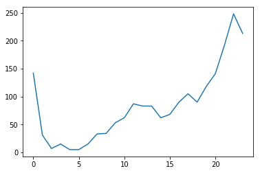

```python
commentsSeries = pd.Series(x.hour for x in comments['created_time']).value_counts().sort_index()

plt.plot(commentsSeries)
plt.show()
```

### Sửa Chart: Lượng Comments theo mỗi giờ - Version 1

- Thêm tên chart, tên trục hoành, trục tung, và thang đo giá trị của từng trục

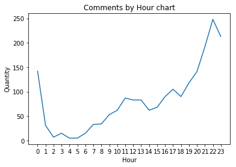

```python
commentsSeries = pd.Series(x.hour for x in comments['created_time']).value_counts().sort_index()
plt.plot(commentsSeries)

plt.title('Comments by Hour chart')
plt.xlabel('Hour')
plt.ylabel('Quantity')
plt.xticks(list(range(0,24)))
plt.show()
```

Chỗ này mình print ra để có thể nắm bắt rõ được data bên trong thế nào.

```python
print (commentsSeries)
```

```
0     142
1      31
2       7
3      15
4       5
5       5
6      15
7      33
8      34
9      53
10     62
11     87
12     83
13     83
14     62
15     68
16     90
17    105
18     90
19    118
20    141
21    192
22    248
23    213
dtype: int64
```

### Tạo Chart: Lượng Comments theo mỗi giờ - Version 2

- Version 2: Dữ liệu vẽ chart sẽ chỉ có của bạn bè - bỏ Owner (data được lấy hết các năm)

Đoạn code dưới đây dùng để lọc ra.

```
comments[(comments['user_id'] != TARGET_USER_ID)]
```

Nếu bạn muốn lọc thêm điều kiện (VD: Comments không có Owner và thuộc năm 2018) thì bạn chỉ cần dấu **&** như sau:

```
comments[(comments['user_id'] != TARGET_USER_ID) & (comments['created_time'].dt.year == 2018)]
```

Một chỗ lưu ý nữa là đối với các Series chứa DateTime (ở đây là **comments['created_time']**), để lấy thành phần bên trong để kiểm tra, bạn chỉ cần **.dt** nữa là được. Ở đây mình muốn kiểm tra về **year** nên Đức đã **.dt.year** và tiến hành biểu thức

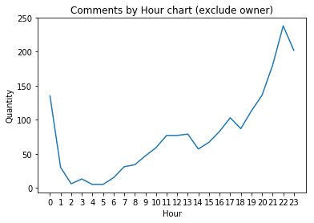

```python
commentsExcludedOwner = comments[(comments['user_id'] != TARGET_USER_ID)]
commentsSeries = pd.Series(x.hour for x in commentsExcludedOwner['created_time']).value_counts().sort_index()
plt.plot(commentsSeries)

plt.title('Comments by Hour chart (exclude owner)')
plt.xlabel('Hour')
plt.ylabel('Quantity')
plt.xticks(list(range(0,24)))
plt.show()
```

```python
print (commentsSeries)
```

```
0     135
1      30
2       6
3      13
4       5
5       5
6      15
7      31
8      34
9      47
10     59
11     77
12     77
13     79
14     57
15     67
16     83
17    103
18     87
19    113
20    136
21    180
22    238
23    202
dtype: int64
```

### Tạo Chart: Lượng Comments theo mỗi giờ - Version 3

- Version 3: Gom 2 chart ở trên thành 1 chart có 2 Line, và thêm 1 line của chỉ riêng Owner
- Mục tiêu: Dễ làm so sánh hơn
- Trước khi **plt.show()**, bạn chỉ cần plt.plot() cho cả 3 Series là được.
- Ngoài ra do plot 1 lần 3 line, bạn sẽ cần **plt.legend()** để đặt tên cho từng line

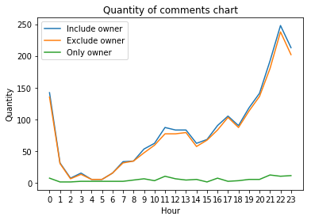

```python
plt.plot(pd.Series(x.hour for x in comments['created_time']).value_counts().sort_index())
plt.plot(pd.Series(x.hour for x in comments[(comments['user_id'] != TARGET_USER_ID)]['created_time']).value_counts().sort_index())
plt.plot(pd.Series(x.hour for x in comments[(comments['user_id'] == TARGET_USER_ID)]['created_time']).value_counts().sort_index())

plt.legend(['Include owner', 'Exclude owner', 'Only owner'])
plt.title('Quantity of comments chart')
plt.xlabel('Hour')
plt.ylabel('Quantity')
plt.xticks(list(range(0,24)))
plt.show()
```

### Tạo Chart: Lượng Comments theo mỗi giờ - Version 4

- Version 4: Tương tự Version 3, nhưng là giới hạn dữ liệu lại trong năm 2017

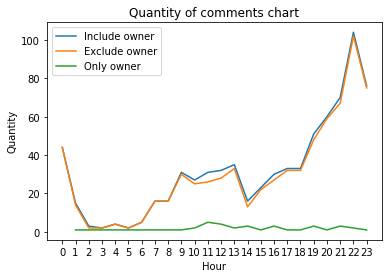

```python
comments2017 = comments[(comments['created_time'].dt.year == 2017)]

plt.plot(pd.Series(x.hour for x in comments2017['created_time']).value_counts().sort_index())
plt.plot(pd.Series(x.hour for x in comments2017[(comments2017['user_id'] != TARGET_USER_ID)]['created_time']).value_counts().sort_index())
plt.plot(pd.Series(x.hour for x in comments2017[(comments2017['user_id'] == TARGET_USER_ID)]['created_time']).value_counts().sort_index())

plt.legend(['Include owner', 'Exclude owner', 'Only owner'])
plt.title('Quantity of comments chart')
plt.xlabel('Hour')
plt.ylabel('Quantity')
plt.xticks(list(range(0,24)))
plt.show()
```

### Tạo Chart: Lượng Comments theo mỗi giờ - Version 5

- Version 5: Lần này cũng là comments theo mỗi giờ, nhưng mỗi Line sẽ là 1 năm (tính đến 2018)
- Trước hết thì mình thử plot chart của số comment từng năm xem thế nào.
  - Mình cũng sẽ cần lấy ra list các năm trong toàn bộ data của mình nữa.
- Sau đó thì mình plot như ví dụ phía trên là OK (và lần này mình sẽ loop qua cái list ở trên để không phải gõ quá nhiều code)

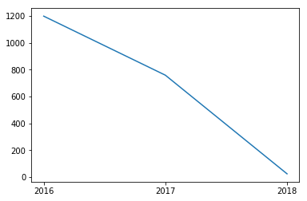

```python
commentsYearSummary = pd.Series(x.year for x in comments['created_time']).value_counts().sort_index()

plt.plot(commentsYearSummary)
plt.xticks(commentsYearSummary.keys().tolist())
plt.show()
```

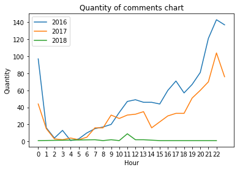

```python
for year in commentsYearSummary.keys().tolist():
    plt.plot(pd.Series(x.hour for x in comments[(comments['created_time'].dt.year == year)]['created_time']).value_counts().sort_index())

plt.legend(commentsYearSummary.keys().tolist())
plt.title('Quantity of comments chart')
plt.xlabel('Hour')
plt.ylabel('Quantity')
plt.xticks(list(range(0,23)))
plt.show()
```

### Bonus Chart: Lượng Comments theo mỗi tháng

- Tương tự Version 3, thay thế **x.hour** thành **x.month**

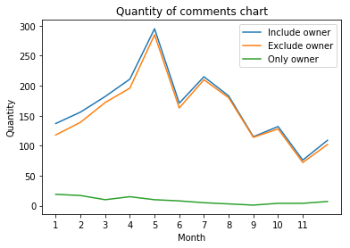

```python
plt.plot(pd.Series(x.month for x in comments['created_time']).value_counts().sort_index())
plt.plot(pd.Series(x.month for x in comments[(comments['user_id'] != TARGET_USER_ID)]['created_time']).value_counts().sort_index())
plt.plot(pd.Series(x.month for x in comments[(comments['user_id'] == TARGET_USER_ID)]['created_time']).value_counts().sort_index())

plt.legend(['Include owner', 'Exclude owner', 'Only owner'])
plt.title('Quantity of comments chart')
plt.xlabel('Month')
plt.ylabel('Quantity')
plt.xticks(list(range(1,12)))
plt.show()
```